# Cell Painting cpg0016-jump Embedding MAE QC

Michael Tran

2026-04-29

This notebook demonstrates the structure and basic use of the final `MultiAssayExperiment` containing well-level Cell Painting embeddings, CellProfiler profiles, and compound annotations.

## Load the MAE

```r
mae <- readRDS(mae_path)

assay_names <- names(experiments(mae))
example_assay <- "cpcnn"
embedding_se <- experiments(mae)[[example_assay]]
embedding_mat <- assay(embedding_se)
cellprofiler_se <- experiments(mae)[["cellprofiler"]]
cellprofiler_mat <- assay(cellprofiler_se)

well_metadata <- as.data.frame(colData(mae)) |>
  as_tibble()

compound_metadata <- as.data.frame(metadata(mae)$Drug.Metadata) |>
  as_tibble()

mae
```

```
## A MultiAssayExperiment object of 2 listed
##  experiments with user-defined names and respective classes.
##  Containing an ExperimentList class object of length 2:
##  [1] cpcnn: SummarizedExperiment with 672 rows and 793683 columns
##  [2] cellprofiler: SummarizedExperiment with 737 rows and 750114 columns
## Functionality:
##  experiments() - obtain the ExperimentList instance
##  colData() - the primary/phenotype DataFrame
##  sampleMap() - the sample coordination DataFrame
##  `$`, `[`, `[[` - extract colData columns, subset, or experiment
##  *Format() - convert into a long or wide DataFrame
##  assays() - convert ExperimentList to a SimpleList of matrices
##  exportClass() - save data to flat files
```

## Dataset Overview

```r
assay_summary <- tibble(
  assay = assay_names,
  feature_type = case_when(
    assay_names == "cpcnn" ~ "embedding vector positions",
    assay_names == "cellprofiler" ~ "scalar morphology features",
    TRUE ~ "numeric profile features"
  ),
  assay_name = vapply(
    assay_names,
    \(assay_name) {
      paste(assayNames(experiments(mae)[[assay_name]]), collapse = ", ")
    },
    character(1)
  ),
  features = vapply(
    assay_names,
    \(assay_name) nrow(experiments(mae)[[assay_name]]),
    integer(1)
  ),
  wells = vapply(
    assay_names,
    \(assay_name) ncol(experiments(mae)[[assay_name]]),
    integer(1)
  ),
  profile_model = vapply(
    assay_names,
    \(assay_name) {
      paste(
        unique(rowData(experiments(mae)[[assay_name]])$Profile.Model),
        collapse = ", "
      )
    },
    character(1)
  )
)

perturbation_counts <- well_metadata |>
  count(Perturbation.Type, name = "wells", sort = TRUE)

assay_overview_tbl <- bind_rows(
  assay_summary |>
    transmute(
      quantity = paste(assay, "features"),
      value = scales::comma(features)
    ),
  assay_summary |>
    transmute(
      quantity = paste(assay, "wells"),
      value = scales::comma(wells)
    )
)

overview_tbl <- tibble(
  quantity = c(
    "Pipeline ID",
    "Pipeline version",
    "Experiments",
    "Assays",
    "Wells in colData",
    "Plates",
    "Sources",
    "Unique compounds",
    "Drug metadata records",
    "Treatment wells",
    "Negative-control wells",
    "Positive-control wells"
  ),
  value = c(
    metadata(mae)$Pipeline$ID,
    metadata(mae)$Pipeline$Version,
    scales::comma(length(experiments(mae))),
    paste(assay_names, collapse = ", "),
    scales::comma(nrow(well_metadata)),
    scales::comma(n_distinct(well_metadata$Plate)),
    scales::comma(n_distinct(well_metadata$Source)),
    scales::comma(n_distinct(well_metadata$JUMP.CP.ID)),
    scales::comma(nrow(compound_metadata)),
    scales::comma(sum(well_metadata$Perturbation.Type == "treatment")),
    scales::comma(sum(well_metadata$Perturbation.Type == "negcon")),
    scales::comma(sum(well_metadata$Perturbation.Type == "poscon"))
  )
) |>
  bind_rows(assay_overview_tbl)

kable(overview_tbl)
```

| quantity | value |
| --- | --- |
| Pipeline ID | cpg0016_emb |
| Pipeline version | v2.0.0 |
| Experiments | 2 |
| Assays | cpcnn, cellprofiler |
| Wells in colData | 793,992 |
| Plates | 1,729 |
| Sources | 10 |
| Unique compounds | 115,730 |
| Drug metadata records | 115,730 |
| Treatment wells | 640,803 |
| Negative-control wells | 88,583 |
| Positive-control wells | 64,606 |
| cpcnn features | 672 |
| cellprofiler features | 737 |
| cpcnn wells | 793,683 |
| cellprofiler wells | 750,114 |

```r
kable(assay_summary)
```

| assay | feature_type | assay_name | features | wells | profile_model |
| --- | --- | --- | --- | --- | --- |
| cpcnn | embedding vector positions | values | 672 | 793683 | cpcnn_zenodo_7114558 |
| cellprofiler | scalar morphology features | values | 737 | 750114 | cellprofiler |

This file contains 2 assays. The `cpcnn` assay stores 672 embedding features across 793,683 wells. The `cellprofiler` assay stores scalar morphology features for the wells where CellProfiler profiles were available.

## Inspect the MAE Structure

The object layout is inspected directly below. The experiment container, assay names, well-level metadata, sample map, and object-level metadata can all be accessed from the printed structure and the code shown in this section.

```r
mae
```

```
## A MultiAssayExperiment object of 2 listed
##  experiments with user-defined names and respective classes.
##  Containing an ExperimentList class object of length 2:
##  [1] cpcnn: SummarizedExperiment with 672 rows and 793683 columns
##  [2] cellprofiler: SummarizedExperiment with 737 rows and 750114 columns
## Functionality:
##  experiments() - obtain the ExperimentList instance
##  colData() - the primary/phenotype DataFrame
##  sampleMap() - the sample coordination DataFrame
##  `$`, `[`, `[[` - extract colData columns, subset, or experiment
##  *Format() - convert into a long or wide DataFrame
##  assays() - convert ExperimentList to a SimpleList of matrices
##  exportClass() - save data to flat files
```

```r
experiments(mae)
```

```
## ExperimentList class object of length 2:
##  [1] cpcnn: SummarizedExperiment with 672 rows and 793683 columns
##  [2] cellprofiler: SummarizedExperiment with 737 rows and 750114 columns
```

```r
colnames(colData(mae))
```

```
##  [1] "Sample.ID"           "JUMP.CP.ID"          "Pubchem.CID"
##  [4] "InChIKey"            "JUMP.CP.SMILES"      "In.AnnotationDB"
##  [7] "AnnotationDB.Name"   "AnnotationDB.SMILES" "Source"
## [10] "Batch"               "Plate"               "Well"
## [13] "Perturbation.Type"
```

```r
head(sampleMap(mae))
```

```
## DataFrame with 6 rows and 3 columns
##            assay               primary               colname
##         <factor>           <character>           <character>
## cpcnn.1    cpcnn Dest210607-134443.N19 Dest210607-134443.N19
## cpcnn.2    cpcnn       GR00003282.AC04       GR00003282.AC04
## cpcnn.3    cpcnn      110000295610.N22      110000295610.N22
## cpcnn.4    cpcnn Dest210809-141809.N05 Dest210809-141809.N05
## cpcnn.5    cpcnn      110000295565.N16      110000295565.N16
## cpcnn.6    cpcnn          UL001789.I43          UL001789.I43
```

```r
names(metadata(mae))
```

```
## [1] "Pipeline"      "Drug.Metadata"
```

## Well-Level Metadata

```r
well_metadata |>
  select(
    Sample.ID,
    JUMP.CP.ID,
    Pubchem.CID,
    InChIKey,
    Source,
    Batch,
    Plate,
    Well,
    Perturbation.Type
  ) |>
  slice_head(n = 8) |>
  kable()
```

| Sample.ID | JUMP.CP.ID | Pubchem.CID | InChIKey | Source | Batch | Plate | Well | Perturbation.Type |
| --- | --- | --- | --- | --- | --- | --- | --- | --- |
| Dest210607-134443.N19 | JCP2022_002169 | 110132473 | ALIGFVWJHCLCCG-UHFFFAOYSA-N | source_10 | 2021_06_07_U2OS_48_hr_run3 | Dest210607-134443 | N19 | treatment |
| GR00003282.AC04 | JCP2022_090265 | 75477277 | UNBDJSUVRUVXTM-UHFFFAOYSA-N | source_9 | 20211013-Run14 | GR00003282 | AC04 | treatment |
| 110000295610.N22 | JCP2022_115320 | 31326 | ZRZNJUXESFHSIO-UHFFFAOYSA-N | source_6 | p211012CPU2OS48hw384exp033JUMP | 110000295610 | N22 | treatment |
| Dest210809-141809.N05 | JCP2022_000983 | 30889490 | AFDSCABMINXZRC-UHFFFAOYSA-N | source_10 | 2021_08_17_U2OS_48_hr_run16 | Dest210809-141809 | N05 | treatment |
| 110000295565.N16 | JCP2022_061641 | 110251711 | NVOQOWPHOZXBRE-UHFFFAOYSA-N | source_6 | p211004CPU2OS48hw384exp031JUMP | 110000295565 | N16 | treatment |
| UL001789.I43 | JCP2022_022717 | 46364319 | FSUQRPQVCRVLNU-UHFFFAOYSA-N | source_1 | Batch6_20221102 | UL001789 | I43 | treatment |
| GR00003386.AE32 | JCP2022_064132 | 875116 | OJDWYGXFEFNPEV-UHFFFAOYSA-N | source_9 | 20210824-Run5 | GR00003386 | AE32 | treatment |
| GR00003390.E17 | JCP2022_012837 | 4667208 | CQMZYBFPWYQAGU-UHFFFAOYSA-N | source_9 | 20210825_Run6 | GR00003390 | E17 | treatment |

The main fields commonly used in downstream analysis are:

- `Sample.ID`: the well identifier used throughout the object. It is the row name of `colData(mae)` and the column name used by assay matrices.
- `Source`: the source-specific study label.
- `Batch`: the batch identifier within a source.
- `Plate` and `Well`: the physical plate and well coordinates.
- `JUMP.CP.ID`: the perturbagen identifier used to join to compound metadata.
- `InChIKey`: the structure-level identifier for the perturbagen.
- `Perturbation.Type`: whether the well is a treatment, negative control (`negcon`), or positive control (`poscon`).

```r
kable(perturbation_counts)
```

| Perturbation.Type | wells |
| --- | --- |
| treatment | 640803 |
| negcon | 88583 |
| poscon | 64606 |

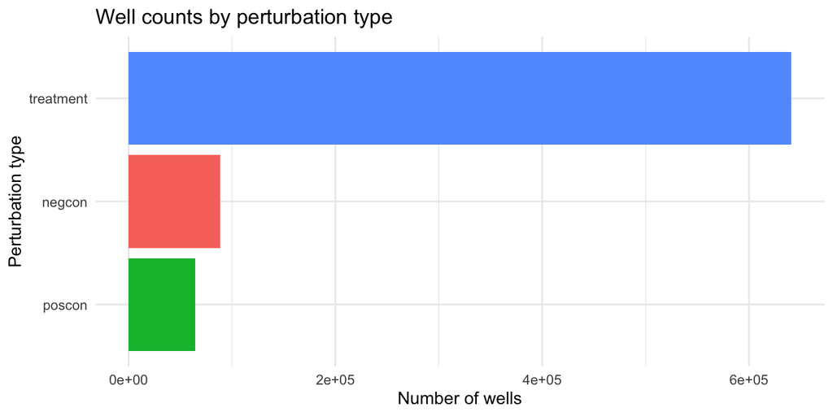

```r
ggplot(
  perturbation_counts,
  aes(
    x = reorder(Perturbation.Type, wells),
    y = wells,
    fill = Perturbation.Type
  )
) +
  geom_col(show.legend = FALSE) +
  labs(
    title = "Well counts by perturbation type",
    x = "Perturbation type",
    y = "Number of wells"
  ) +
  coord_flip()
```

Treatment compound replication is summarized below. This view focuses on treatments; controls are represented separately in the perturbation summaries.

```r
compound_replicates <- well_metadata |>
  filter(Perturbation.Type == "treatment") |>
  count(JUMP.CP.ID, name = "wells", sort = TRUE) |>
  left_join(
    compound_metadata |>
      select(
        JUMP.CP.ID,
        AnnotationDB.Name,
        Pubchem.CID,
        InChIKey,
        Control.Name
      ),
    by = "JUMP.CP.ID"
  )

replicate_summary_tbl <- tibble(
  quantity = c(
    "Treatment compounds",
    "Treatment compounds with more than one well",
    "Median wells per treatment compound",
    "95th percentile wells per treatment compound",
    "Maximum wells for one treatment compound"
  ),
  value = c(
    scales::comma(nrow(compound_replicates)),
    scales::comma(sum(compound_replicates$wells > 1)),
    scales::comma(median(compound_replicates$wells)),
    scales::comma(quantile(compound_replicates$wells, 0.95, names = FALSE)),
    scales::comma(max(compound_replicates$wells))
  )
)

kable(replicate_summary_tbl)
```

| quantity | value |
| --- | --- |
| Treatment compounds | 115,720 |
| Treatment compounds with more than one well | 115,719 |
| Median wells per treatment compound | 5 |
| 95th percentile wells per treatment compound | 9 |
| Maximum wells for one treatment compound | 58 |

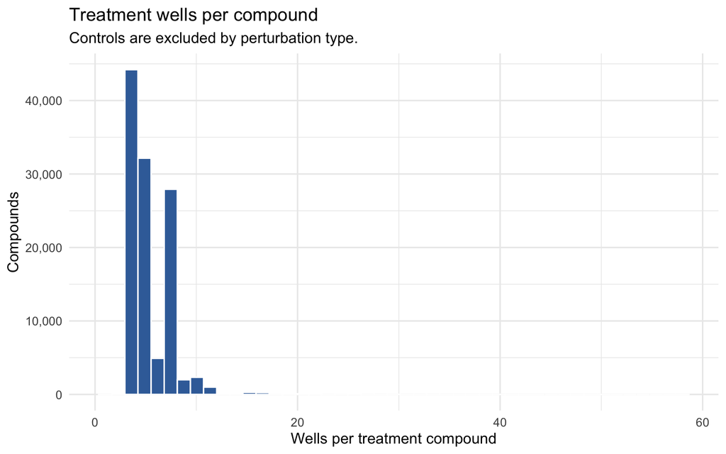

```r
ggplot(
  compound_replicates,
  aes(x = wells)
) +
  geom_histogram(bins = 45, fill = "#3B6EA8", color = "white") +
  scale_x_continuous(labels = scales::comma) +
  scale_y_continuous(labels = scales::comma) +
  labs(
    title = "Treatment wells per compound",
    subtitle = "Controls are excluded by perturbation type.",
    x = "Wells per treatment compound",
    y = "Compounds"
  )
```

## Inspect the CPCNN Assay

```r
kable(head(as.data.frame(rowData(embedding_se)), 3))
```

|  | Feature.ID | Feature.Source | Feature.Index | Profile.Model | Assay.Name |
| --- | --- | --- | --- | --- | --- |
| all_emb_0001 | all_emb_0001 | all_emb | 1 | cpcnn_zenodo_7114558 | cpcnn |
| all_emb_0002 | all_emb_0002 | all_emb | 2 | cpcnn_zenodo_7114558 | cpcnn |
| all_emb_0003 | all_emb_0003 | all_emb | 3 | cpcnn_zenodo_7114558 | cpcnn |

```r
dim(rowData(embedding_se))
```

```
## [1] 672   5
```

The `cpcnn` experiment is a `SummarizedExperiment` with one assay called `values`. Rows are embedding features and columns are wells.

```r
tibble(
  metric = c("Embedding features per well", "Wells in assay"),
  value = c(nrow(embedding_mat), ncol(embedding_mat))
) |>
  kable()
```

| metric | value |
| --- | --- |
| Embedding features per well | 672 |
| Wells in assay | 793683 |

The UMAP below is a visualization of a reproducible sample of 1,000 treatment wells from the `cpcnn` assay. Each point is one well-level profile.

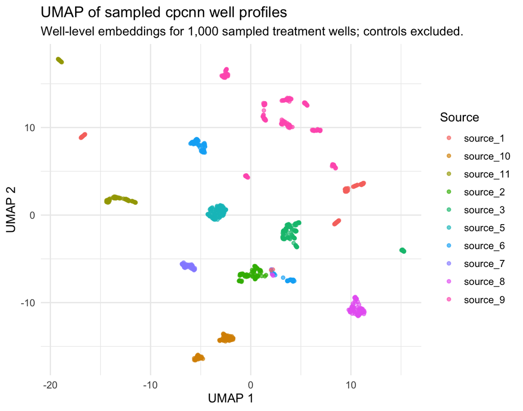

```r
set.seed(20260429)

cpcnn_treatment_wells <- well_metadata |>
  filter(
    Perturbation.Type == "treatment",
    Sample.ID %in% colnames(embedding_mat)
  ) |>
  left_join(
    compound_metadata |>
      select(JUMP.CP.ID, Control.Name),
    by = "JUMP.CP.ID"
  ) |>
  filter(is.na(Control.Name))

umap_sample_n <- min(1000L, nrow(cpcnn_treatment_wells))

umap_wells <- cpcnn_treatment_wells |>
  slice_sample(n = umap_sample_n)

umap_embeddings <- embedding_mat[, umap_wells$Sample.ID, drop = FALSE]

umap_input <- scale(t(umap_embeddings))
umap_input[is.na(umap_input)] <- 0

umap_layout <- uwot::umap(
  umap_input,
  n_neighbors = 15,
  min_dist = 0.2,
  metric = "cosine",
  n_threads = 1,
  n_sgd_threads = 1,
  verbose = FALSE
)

umap_tbl <- as_tibble(umap_layout, .name_repair = \(x) c("UMAP1", "UMAP2")) |>
  bind_cols(
    umap_wells |>
      select(Sample.ID, JUMP.CP.ID, Source, Plate, Well)
  )

ggplot(
  umap_tbl,
  aes(x = UMAP1, y = UMAP2, color = Source)
) +
  geom_point(alpha = 0.65, size = 1.3) +
  labs(
    title = "UMAP of sampled cpcnn well profiles",
    subtitle = paste0(
      "Well-level embeddings for ",
      scales::comma(nrow(umap_tbl)),
      " sampled treatment wells; controls excluded."
    ),
    x = "UMAP 1",
    y = "UMAP 2",
    color = "Source"
  )
```

```r
embedding_mat[1:6, 1:4]
```

```
##              Dest210607-134443.N19 GR00003282.AC04 110000295610.N22
## all_emb_0001             1.7471794       0.9005039         1.455983
## all_emb_0002             2.5285974       2.6223581         2.704039
## all_emb_0003             1.4317852       2.1683698         1.120903
## all_emb_0004             0.8901504       1.6842115         1.149817
## all_emb_0005             1.0509490       2.5887990         1.653135
## all_emb_0006             0.8935499       1.5391492         1.083898
##              Dest210809-141809.N05
## all_emb_0001             1.4962467
## all_emb_0002             2.1586897
## all_emb_0003             2.9967451
## all_emb_0004             0.6773452
## all_emb_0005             1.1195399
## all_emb_0006             0.9702294
```

The `cpcnn` assay columns are represented in `colData(mae)`.

```r
all(colnames(embedding_mat) %in% well_metadata$Sample.ID)
```

```
## [1] TRUE
```

## Inspect the CellProfiler Assay

The `cellprofiler` experiment has the same `SummarizedExperiment` layout as `cpcnn`: one `values` assay with features as rows and wells as columns. The main difference is feature meaning. `cpcnn` rows are embedding vector positions, while `cellprofiler` rows are scalar morphology features from the CellProfiler profile table.

```r
kable(head(as.data.frame(rowData(cellprofiler_se)), 8))
```

|  | Feature.ID | Feature.Source | Feature.Index | Profile.Model | Assay.Name |
| --- | --- | --- | --- | --- | --- |
| X_1 | X_1 | X_1 | 1 | cellprofiler | cellprofiler |
| X_2 | X_2 | X_2 | 1 | cellprofiler | cellprofiler |
| X_3 | X_3 | X_3 | 1 | cellprofiler | cellprofiler |
| X_4 | X_4 | X_4 | 1 | cellprofiler | cellprofiler |
| X_5 | X_5 | X_5 | 1 | cellprofiler | cellprofiler |
| X_6 | X_6 | X_6 | 1 | cellprofiler | cellprofiler |
| X_7 | X_7 | X_7 | 1 | cellprofiler | cellprofiler |
| X_8 | X_8 | X_8 | 1 | cellprofiler | cellprofiler |

```r
tibble(
  metric = c(
    "CellProfiler features per well",
    "CellProfiler wells in assay",
    "CellProfiler wells represented in colData",
    "CellProfiler wells not in colData"
  ),
  value = c(
    nrow(cellprofiler_mat),
    ncol(cellprofiler_mat),
    sum(colnames(cellprofiler_mat) %in% well_metadata$Sample.ID),
    sum(!(colnames(cellprofiler_mat) %in% well_metadata$Sample.ID))
  )
) |>
  kable()
```

| metric | value |
| --- | --- |
| CellProfiler features per well | 737 |
| CellProfiler wells in assay | 750114 |
| CellProfiler wells represented in colData | 750114 |
| CellProfiler wells not in colData | 0 |

```r
cellprofiler_mat[1:6, 1:4]
```

```
##     1053601947.K24 1053601817.K24 GR00004392.Y45 EC000080.C24
## X_1      0.9073636      1.0564263    -1.11075437   -0.7961960
## X_2      0.8933774     -0.1732340     0.36920089    0.1567714
## X_3     -0.2657616     -0.1964321     0.02818934   -0.7304401
## X_4      0.0767049      1.0175720    -0.96340978   -0.9040873
## X_5     -0.5475310     -0.4958429     0.87367624   -0.2574983
## X_6     -0.9669507      1.2100601    -0.69021785    0.6940953
```

## Compound Metadata

```r
compound_preview <- compound_metadata |>
  select(
    JUMP.CP.ID,
    InChIKey,
    Perturbation.Type,
    AnnotationDB.Name,
    Pubchem.CID,
    In.AnnotationDB
  ) |>
  slice_head(n = 8)

kable(compound_preview)
```

| JUMP.CP.ID | InChIKey | Perturbation.Type | AnnotationDB.Name | Pubchem.CID | In.AnnotationDB |
| --- | --- | --- | --- | --- | --- |
| JCP2022_000001 | AAAHWCWPZPSPIW-UHFFFAOYSA-N | treatment | [4-[2-(Dimethylamino)ethoxy]phenyl]-[2-[6-(2-ethylimidazol-1-yl)-2-pyridinyl]pyrrolidin-1-yl]methanone | 110094592 | TRUE |
| JCP2022_000002 | AAAJHRMBUHXWLD-UHFFFAOYSA-N | treatment | 1-(4-chlorobenzyl)tetrahydropyrimidin-2(1H)-one | 5076487 | TRUE |
| JCP2022_000004 | AAANUZMCJQUYNX-UHFFFAOYSA-N | treatment | NA | NA | FALSE |
| JCP2022_000005 | AAAQFGUYHFJNHI-UHFFFAOYSA-N | treatment | 4H-[1,2,4]Triazolo[4,3-a][1,4]benzodiazepine-4-acetamide, 6-(4-chlorophenyl)-N-ethyl-8-methoxy-1-methyl- | 52934829 | TRUE |
| JCP2022_000006 | AAAROXVLYNJINN-UHFFFAOYSA-N | treatment | 5-(1-Tert-butyl-5-cyclopropylpyrazol-3-yl)-3-(1-methylpyrazol-4-yl)-1,2,4-oxadiazole | 72019641 | TRUE |
| JCP2022_000007 | AAATVJFGQAZXQO-UHFFFAOYSA-N | treatment | [1-(1H-indol-3-yl)-1-oxopropan-2-yl] 2-[(3,5-dimethyl-1,2-oxazol-4-yl)methylsulfanyl]benzoate | 16324273 | TRUE |
| JCP2022_000008 | AAAUIKUIDRZZQT-UHFFFAOYSA-N | treatment | N-(3-chlorophenyl)-2-(3-methyl-2-oxo-5-phenyl-2,3-dihydro-1H-1,4-benzodiazepin-1-yl)butanamide | 15998487 | TRUE |
| JCP2022_000009 | AAAZRMGPBSWFDK-UHFFFAOYSA-N | treatment | 2-(2-(4-(2-(Trifluoromethyl)phenylsulfonyl)piperazin-1-yl)acetamido)thiophene-3-carboxamide | 16231644 | TRUE |

This table is stored once at the object level instead of being repeated on every well. The join key is `JUMP.CP.ID`.

The `Perturbation.Type` labels also appear in the compound metadata. In this context, `negcon` denotes negative controls and `poscon` denotes positive controls.

For compounds represented in the `cpcnn` assay, most records are enriched with AnnotationDB names and identifiers. Some compounds, such as `JCP2022_000004`, do not have mapped AnnotationDB names, PubChem CIDs, or AnnotationDB SMILES. The overall breakdown is shown below.

```r
cpcnn_compound_metadata <- well_metadata |>
  filter(Sample.ID %in% colnames(embedding_mat)) |>
  distinct(JUMP.CP.ID) |>
  left_join(compound_metadata, by = "JUMP.CP.ID")

annotation_availability <- cpcnn_compound_metadata |>
  mutate(
    annotation_status = if_else(
      In.AnnotationDB,
      "AnnotationDB enriched",
      "No AnnotationDB match",
      missing = "No AnnotationDB match"
    )
  ) |>
  count(annotation_status, name = "compounds") |>
  mutate(
    fraction = compounds / sum(compounds),
    percent = scales::percent(fraction, accuracy = 0.1),
    label = paste0(
      annotation_status,
      "\n",
      scales::comma(compounds),
      " (",
      percent,
      ")"
    )
  )

kable(
  annotation_availability |>
    select(annotation_status, compounds, percent)
)
```

| annotation_status | compounds | percent |
| --- | --- | --- |
| AnnotationDB enriched | 106566 | 92.1% |
| No AnnotationDB match | 9164 | 7.9% |

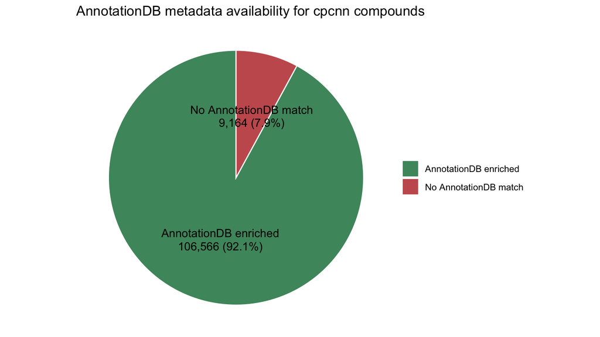

```r
ggplot(
  annotation_availability,
  aes(x = "", y = fraction, fill = annotation_status)
) +
  geom_col(width = 1, color = "white") +
  geom_text(
    aes(label = label),
    position = position_stack(vjust = 0.5),
    lineheight = 0.95
  ) +
  coord_polar(theta = "y") +
  scale_fill_manual(values = c("#4C956C", "#C75C5C")) +
  labs(
    title = "AnnotationDB metadata availability for cpcnn compounds",
    fill = NULL
  ) +
  theme_void()
```

```r
negcon_examples <- compound_metadata |>
  filter(Perturbation.Type == "negcon") |>
  select(
    JUMP.CP.ID,
    Control.Name,
    AnnotationDB.Name,
    Pubchem.CID
  ) |>
  slice_head(n = 3)

poscon_examples <- compound_metadata |>
  filter(Perturbation.Type == "poscon") |>
  arrange(desc(JUMP.CP.ID)) |>
  select(
    JUMP.CP.ID,
    Control.Name,
    AnnotationDB.Name,
    Pubchem.CID
  ) |>
  slice_head(n = 3)

kable(negcon_examples, caption = "Example negative-control compounds")
```

Example negative-control compounds

| JUMP.CP.ID | Control.Name | AnnotationDB.Name | Pubchem.CID |
| --- | --- | --- | --- |
| JCP2022_033924 | DMSO | Dimethyl Sulfoxide | 679 |

```r
kable(poscon_examples, caption = "Example positive-control compounds")
```

Example positive-control compounds

| JUMP.CP.ID | Control.Name | AnnotationDB.Name | Pubchem.CID |
| --- | --- | --- | --- |
| JCP2022_085227 | aloxistatin | Ethyl epoxysuccinyl-leucylamido-3-methylbutane | 3189 |
| JCP2022_064022 | NVS-PAK1-1 | 3-((2-Chloro-5-(2,2-difluoroethyl)-8-fluoro-5H-dibenzo[b,e][1,4]diazepin-11-yl)amino)-N-isopropylpyrrolidine-1-carboxamide | 138115195 |
| JCP2022_050797 | quinidine | Cinchonan-9-ol, 6’-methoxy-, (8alpha,9R)- | 1065 |

## Demonstrate Basic Access Patterns

### Pull One Plate and Its Embeddings

```r
plate_id <- well_metadata$Plate[1]

plate_wells <- well_metadata |>
  filter(Plate == plate_id, Sample.ID %in% colnames(embedding_mat))

plate_embeddings <- embedding_mat[, plate_wells$Sample.ID, drop = FALSE]

kable(
  plate_wells |>
    select(
      Sample.ID,
      Well,
      JUMP.CP.ID,
      Perturbation.Type
    ) |>
    slice_head(n = 8)
)
```

| Sample.ID | Well | JUMP.CP.ID | Perturbation.Type |
| --- | --- | --- | --- |
| Dest210607-134443.N19 | N19 | JCP2022_002169 | treatment |
| Dest210607-134443.G20 | G20 | JCP2022_093263 | treatment |
| Dest210607-134443.H04 | H04 | JCP2022_095326 | treatment |
| Dest210607-134443.O14 | O14 | JCP2022_037505 | treatment |
| Dest210607-134443.F24 | F24 | JCP2022_037716 | poscon |
| Dest210607-134443.K17 | K17 | JCP2022_019618 | treatment |
| Dest210607-134443.I06 | I06 | JCP2022_019219 | treatment |
| Dest210607-134443.C15 | C15 | JCP2022_037886 | treatment |

```r
dim(plate_embeddings)
```

```
## [1] 672 382
```

### Annotate Wells with Compound Metadata

```r
plate_treatment_wells <- plate_wells |>
  filter(Perturbation.Type == "treatment")

plate_treatment_annotated <- plate_treatment_wells |>
  select(
    Sample.ID,
    Source,
    Plate,
    Well,
    JUMP.CP.ID
  ) |>
  left_join(
    compound_metadata |>
      select(
        JUMP.CP.ID,
        AnnotationDB.Name,
        Pubchem.CID,
        In.AnnotationDB
      ),
    by = "JUMP.CP.ID"
  )

kable(slice_head(plate_treatment_annotated, n = 8))
```

| Sample.ID | Source | Plate | Well | JUMP.CP.ID | AnnotationDB.Name | Pubchem.CID | In.AnnotationDB |
| --- | --- | --- | --- | --- | --- | --- | --- |
| Dest210607-134443.N19 | source_10 | Dest210607-134443 | N19 | JCP2022_002169 | 3-(2-ethylimidazol-1-yl)-1-[3-(4-methyl-1H-pyrazol-5-yl)morpholin-4-yl]propan-1-one | 110132473 | TRUE |
| Dest210607-134443.G20 | source_10 | Dest210607-134443 | G20 | JCP2022_093263 | 1-[2-[6-[(2-Methoxyphenyl)methyl]-2-pyridinyl]pyrrolidin-1-yl]-2-pyrrolidin-1-ylethanone | 110254637 | TRUE |
| Dest210607-134443.H04 | source_10 | Dest210607-134443 | H04 | JCP2022_095326 | NA | NA | FALSE |
| Dest210607-134443.O14 | source_10 | Dest210607-134443 | O14 | JCP2022_037505 | 7-cyclopentyl-2-(N-methylglycyl)-2,7-diazaspiro[4.5]decan-6-one | 72912006 | TRUE |
| Dest210607-134443.K17 | source_10 | Dest210607-134443 | K17 | JCP2022_019618 | NA | NA | FALSE |
| Dest210607-134443.I06 | source_10 | Dest210607-134443 | I06 | JCP2022_019219 | N-{2-[4-(furan-2-yl)phenyl]-2-hydroxyethyl}-1-methyl-1H-imidazole-4-sulfonamide | 126854880 | TRUE |
| Dest210607-134443.C15 | source_10 | Dest210607-134443 | C15 | JCP2022_037886 | 1-(3-chlorophenyl)-3-((6-(1-methyl-1H-pyrazol-5-yl)pyridin-3-yl)methyl)urea | 121023442 | TRUE |
| Dest210607-134443.D03 | source_10 | Dest210607-134443 | D03 | JCP2022_051500 | 2-(4-Chlorophenoxy)-2-methyl-1-[4-(thiolan-3-yl)-1,4-diazepan-1-yl]propan-1-one | 134160972 | TRUE |

The same join pattern works for any well subset:

```r
treatment_wells <- well_metadata |>
  filter(
    Perturbation.Type == "treatment",
    Sample.ID %in% colnames(embedding_mat)
  )

treatment_embeddings <- embedding_mat[, treatment_wells$Sample.ID, drop = FALSE]

treatment_annotations <- treatment_wells |>
  left_join(
    compound_metadata,
    by = "JUMP.CP.ID"
  )
```

### Extract Embeddings for a Small Well Set

```r
example_wells <- plate_treatment_wells$Sample.ID[seq_len(min(
  4,
  nrow(plate_treatment_wells)
))]

embedding_mat[1:10, example_wells, drop = FALSE]
```

```
##              Dest210607-134443.N19 Dest210607-134443.G20 Dest210607-134443.H04
## all_emb_0001             1.7471794             1.5646025             1.6318797
## all_emb_0002             2.5285974             2.4691734             2.5115931
## all_emb_0003             1.4317852             1.5929955             1.4785525
## all_emb_0004             0.8901504             0.9677522             0.8726900
## all_emb_0005             1.0509490             1.0516798             1.1063930
## all_emb_0006             0.8935499             0.8201179             0.9844046
## all_emb_0007             1.6671696             1.3333355             1.6165138
## all_emb_0008             0.7661944             1.1351831             1.0195005
## all_emb_0009             1.0824745             1.1245739             1.0411267
## all_emb_0010             0.7689299             0.7754836             0.7757193
##              Dest210607-134443.O14
## all_emb_0001             1.7203033
## all_emb_0002             2.6052914
## all_emb_0003             1.4772871
## all_emb_0004             0.9501830
## all_emb_0005             1.1200948
## all_emb_0006             0.8205119
## all_emb_0007             1.9542652
## all_emb_0008             0.5749847
## all_emb_0009             1.1315907
## all_emb_0010             0.8126057
```

This gives a small feature-by-well slice. For modeling or distance calculations, the wells are typically subset first and the result is then kept as a matrix.

### Build One Mean Profile Per Compound

```r
treatment_wells <- well_metadata |>
  filter(
    Perturbation.Type == "treatment",
    Sample.ID %in% colnames(embedding_mat)
  )

example_compounds <- treatment_wells |>
  count(JUMP.CP.ID, name = "n_wells", sort = TRUE) |>
  filter(n_wells > 1) |>
  slice_head(n = 5)

example_treatment_wells <- treatment_wells |>
  semi_join(example_compounds, by = "JUMP.CP.ID")

treatment_embeddings <- embedding_mat[,
  example_treatment_wells$Sample.ID,
  drop = FALSE
]

compound_means <- rowsum(
  x = t(treatment_embeddings),
  group = example_treatment_wells$JUMP.CP.ID,
  reorder = FALSE
)

compound_counts <- table(example_treatment_wells$JUMP.CP.ID)

compound_means <- compound_means /
  as.numeric(compound_counts[rownames(compound_means)])

compound_mean_preview <- as.data.frame(
  compound_means[, seq_len(min(6, ncol(compound_means))), drop = FALSE],
  check.names = FALSE
) |>
  rownames_to_column("JUMP.CP.ID") |>
  as_tibble() |>
  left_join(example_compounds, by = "JUMP.CP.ID") |>
  select(JUMP.CP.ID, n_wells, everything())

kable(compound_mean_preview)
```

| JUMP.CP.ID | n_wells | all_emb_0001 | all_emb_0002 | all_emb_0003 | all_emb_0004 | all_emb_0005 | all_emb_0006 |
| --- | --- | --- | --- | --- | --- | --- | --- |
| JCP2022_109350 | 49 | 1.089930 | 2.499555 | 2.354518 | 1.434030 | 1.480916 | 0.7527553 |
| JCP2022_101934 | 58 | 1.272925 | 2.511254 | 2.199807 | 1.440963 | 1.485834 | 0.7696769 |
| JCP2022_018628 | 47 | 1.131040 | 2.486283 | 2.440456 | 1.597452 | 1.544299 | 0.6941598 |
| JCP2022_072565 | 41 | 1.071003 | 2.490514 | 2.578724 | 1.625687 | 1.563458 | 0.6468159 |
| JCP2022_050997 | 43 | 1.245778 | 2.509316 | 2.164143 | 1.424489 | 1.450678 | 0.7753809 |

```r
dim(compound_means)
```

```
## [1]   5 672
```

This preview averages the `cpcnn` embeddings for a few replicated treatment compounds. After this step, `compound_means` has one row per compound and one column per embedding feature.